# Further Topics in Statistics and Bioinformatics

Christopher Yau

March 1, 2016

# Introduction

The purpose of this course is to introduce ideas and concepts that are central to the use and application of statistical ideas in bioinformatics problems.

We will only focus on just a couple of methods but explore the associated techniques that are required to make them useful in practice.

There are a wide variety of backgrounds and experiences in this group. The course will provide direction but **you** can manage your own learning.

# Problem

The goal of clustering is to partition $n$ objects into $k$ groups.

This is a universal problem in bioinformatics, e.g. clustering gene expression profiles.

Questions:

- How many groups/clusters?
- How do we determine the partitions?

We will study the [$k$-means](https://en.wikipedia.org/wiki/K-means_clustering) clustering method in this exercise.

This is not the only clustering method but the goal of today is not to focus on the technique itself but the scientific framework in which clustering is applied.

# Learning Outcomes

The learning outcomes are to understand:

1. The functionality of the $k$-means clustering algorithm and its assumptions.
2. The concept of overfitting and methods to avoid this.
3. To implement, using R, functions that perform these tasks.

We will use directed self-learning to help you understand these ideas.

Learn at your own pace.

# $k$-means clustering

We want to partition $n$ objects into $k$ groups.

**Criterion**: Minimise the within-cluster sum of squared distances of each object to its assigned group center.

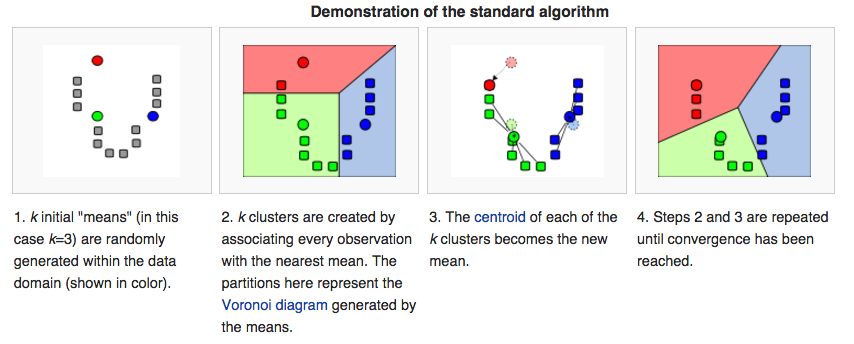

Image Source: Wikipedia

There are $k^n$ possible clustering configurations.

This problem is NP-hard so heuristic algorithms are required. The most common variant is Lloyd’s algorithm.

# Practical

Most exercises come with the solution.

1. Less experienced programmers can re-write or copy + paste and focus on understanding what the code does.
2. More experienced programmers can tackle the open-ended extended exercises at the end.

## Setting up

Before we explore how $k$-means clustering works, we will write some code to generate some simulated data.

Simulated data will help us explore and understand the properties of the method.

The following R code will allow us to generate:

1. 200 2-dimensional measurements for 5 classes
2. The 5 classes will appear with approximate frequency 20%, 20%, 30%, 20% and 10%
3. The 5 classes will have different “centers” ($m$) but the same “spreads” (covariances) ($V$)

```r
  d <- 2 # simulate two-dimensional data
  n <- 200 # simulate 200 data points
  K <- 5 # number of classes
  w <- c(0.2, 0.2, 0.3, 0.2, 0.1) # frequencies of each class
  m <- matrix( nrow=K, ncol=d ) # class centers
  m[1, ] = c(-3, 3)
  m[2, ] = c(0, 0)
  m[3, ] = c(2, 2)
  m[4, ] = c(-6, 0)
  m[5, ] = c(6, 0)
  V <- vector("list", K) # class covariance matrices
  for ( k in 1:K ) {
    V[[k]] <- matrix( c(1,0,0,1), d, d)
  }
```

Now, lets simulate the class assignments and observations for the $n$ objects:

```r
  library(MASS) # we need this to use the mvrnorm function
  z <- sample.int(K, n, replace=TRUE, prob=w) # simulate the class assignments
  x <- matrix(nrow=n, ncol=d) # initialise a matrix of zeros to hold simulated data
  for ( i in 1:n ) {
    # get the class assignment for this data point
    k <- z[i]
    # simulate data from a multivariate normal distribution based on the center and covariance matrix for this class
    x[i, ] <- mvrnorm(n = 1, m[k, ], V[[k]])
  }
```

Lets plot this simulated data:

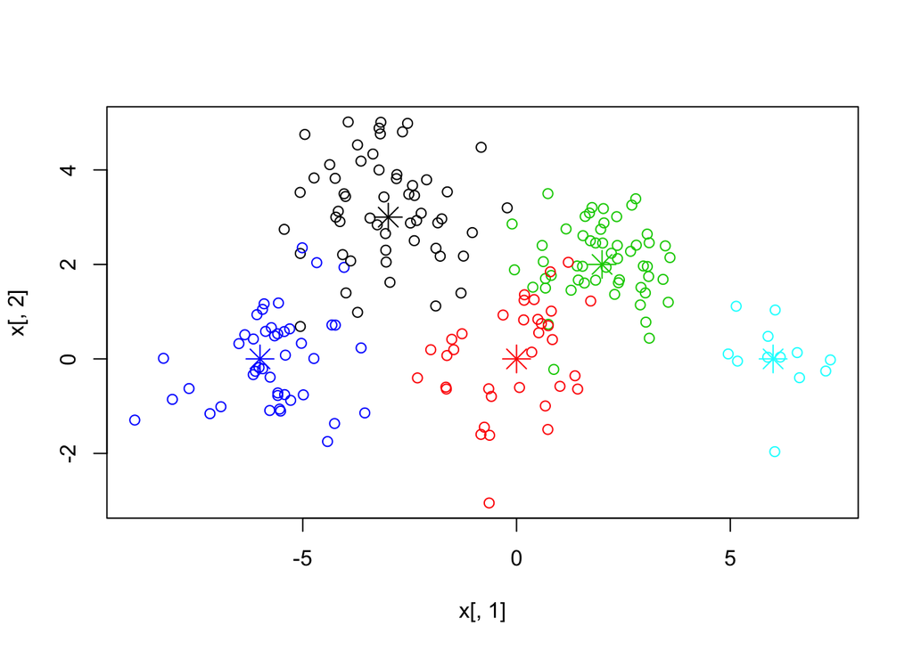

```r
  plot(x[, 1], x[, 2], col=z) # give each point a color according to its class
  points(m, col=1:K, pch=8, cex=2) # plot centers
```

**EXERCISE**

1. Modify the code and specify your own covariance matrices $V$ (note - the matrices must be symmetric, e.g. c(1, -1, -1, 1) is allowed but c(1, -0.5, 0.5, 1) is not ). Try to understand how changing the covariance matrices changes the distribution of the simulated data.

### Using the R function

The R function to apply $k$-means is called “kmeans”.

We will use it to cluster the data stored in the matrix **x** into **K** groups storing the output in **kc**.

```r
  maxiters <- 30
  (kc <- kmeans(x, K, iter=maxiters)) # run k-means
```

```
## K-means clustering with 5 clusters of sizes 43, 56, 24, 43, 34
##
## Cluster means:
##            [,1]       [,2]
## 1 -5.7002074935 -0.1136052
## 2  3.1585135739  1.6860778
## 3 -1.7797342205  2.7939733
## 4  0.0009983708  0.2936459
## 5 -3.8584433516  3.5031087
##
## Clustering vector:
##   [1] 4 3 4 2 2 4 2 3 2 2 4 5 1 4 1 3 4 5 2 2 3 1 4 3 5 4 1 4 1 2 4 2 4 2 1
##  [36] 1 4 5 1 4 5 2 4 4 1 4 5 2 5 4 3 2 5 4 5 4 2 3 1 1 5 2 4 2 5 1 1 4 4 3
##  [71] 1 2 4 2 1 2 4 4 2 5 2 3 4 3 3 3 1 1 4 1 2 2 4 2 2 2 5 4 1 4 5 4 1 5 3
## [106] 5 4 4 4 1 3 5 2 2 1 4 5 1 1 2 5 4 1 2 3 4 5 2 5 2 5 4 2 2 5 2 2 4 2 1
## [141] 3 5 2 2 3 2 2 1 2 2 1 2 1 3 2 1 3 5 2 1 5 3 1 1 4 2 2 3 1 3 4 2 5 5 4
## [176] 1 1 1 5 2 5 5 2 2 3 1 1 4 1 2 1 2 5 1 2 2 3 5 5 1
##
## Within cluster sum of squares by cluster:
## [1]  83.38227 226.89354  35.94878 101.40037  54.62426
##  (between_SS / total_SS =  83.8 %)
##
## Available components:
##
## [1] "cluster"      "centers"      "totss"        "withinss"
## [5] "tot.withinss" "betweenss"    "size"         "iter"
## [9] "ifault"
```

The contents of **kc** tells us:

1. The number of data points assigned to each group.
2. The cluster means found.
3. The clustering assignments.
4. The ratio of within-cluster sum of squared distances by each cluster.

### Comparing to the truth

The table() function allows us to compare the true and $k$-means derived clustering assignments.

```r
  table(z, kc$cluster)
```

```
##
## z    1  2  3  4  5
##   1  2  0 22  0 31
##   2  0  2  0 33  0
##   3  0 42  2 10  0
##   4 41  0  0  0  3
##   5  0 12  0  0  0
```

**EXERCISE**

1. What do you notice about the labelling of the output?

Another approach to compare clustering assignments is to use the [Adjusted Rand Index](https://en.wikipedia.org/wiki/Rand_index#Adjusted_Rand_index):

```r
  library(mclust)
  ari <- adjustedRandIndex(z, kc$cluster)
  print(ari)
```

```
## [1] 0.6087895
```

The adjusted Rand index is a number between 0 and 1 where 0 indicates no clustering concordance and 1 indicates perfect clustering concordance.

### Plot the output

You can plot the clustering output using a different colour for each cluster.

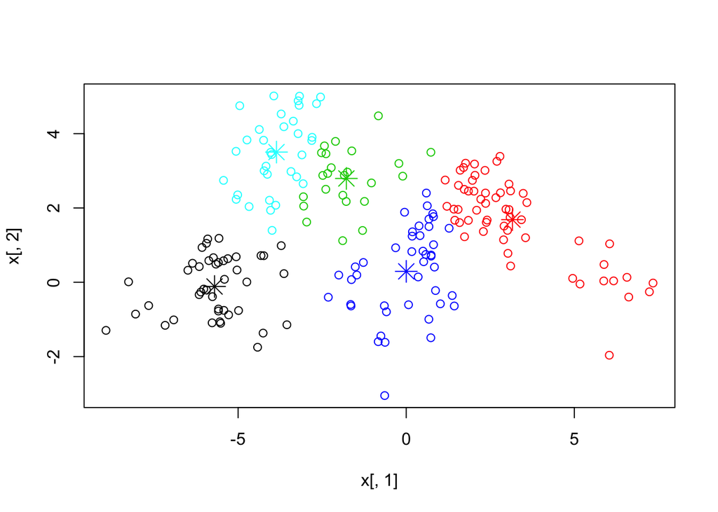

```r
  plot(x[, 1], x[, 2], col=kc$cluster)
  points(kc$centers, col=1:K, pch=8, cex=2)
```

Things to note:

1. The cluster labels reported by $k$-means do not necessarily match our original labels (label-invariant)
2. How do we choose $k$?
3. $k$-means does not recover the original classifications.

**EXERCISE**

Generate different types of data (different means and covariances), investigate how $k$-means performs under these scenarios:

1. Every cluster has the same covariance matrix.
2. Each cluster has a different covariance matrix but the distributions are spherical. This means the covariances matrices must look like:
   $$\left[ \begin{matrix}
   x & 0 \\
   0 & x \\
   \end{matrix} \right]$$
   where $x$ can be any positive number.
3. Each cluster has a different and arbitrary covariance matrix.

## Akaike Information Criterion

As the number of clusters used in $k$-means increases, the better the fit of the cluster model to the data.

This is an example of **overfitting** – we are using an overly complex model to explain some data.

To counteract this effect, we can apply an “information criterion”, which penalises the complexity of a model – in this case, larger $k$’s.

The [Akaike Information Criterion](https://en.wikipedia.org/wiki/Akaike_information_criterion) (AIC) is one example and the following code example shows an implementation:

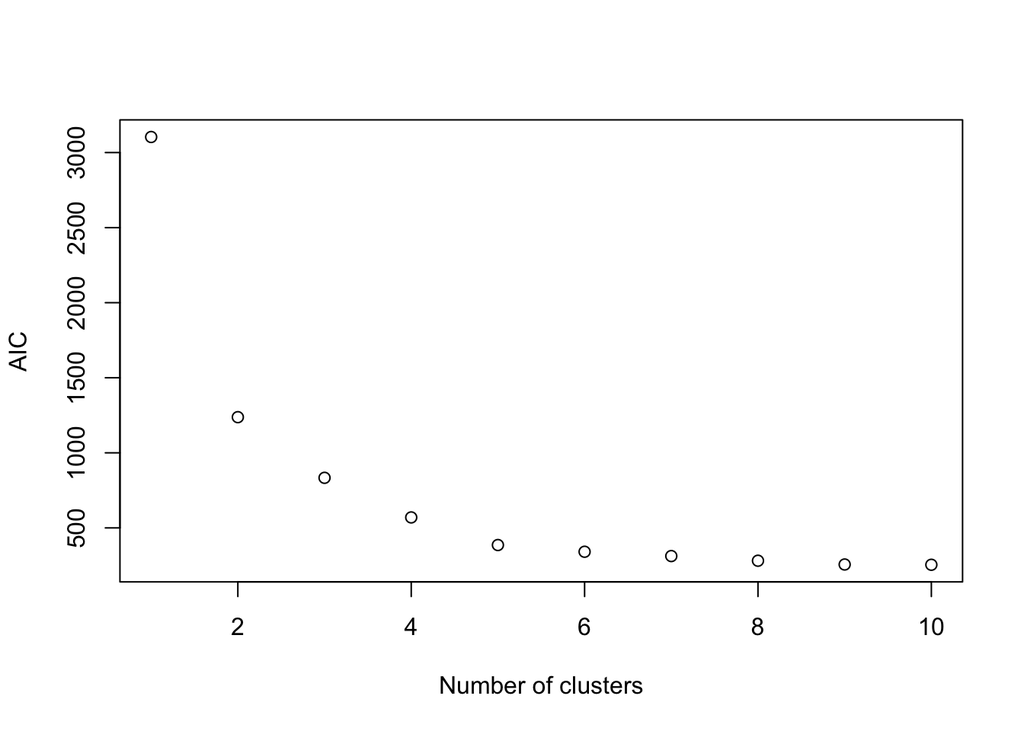

```r
  kmeansAIC = function(fit){

    m <- ncol(fit$centers)
    n <- length(fit$cluster)
    k <- nrow(fit$centers)
    D <- fit$tot.withinss
    return(D + 2*m*k)

  }

  Kmax <- 10
  aic <- rep(0, Kmax)
  for ( k in 1:Kmax ) {
    kc <- kmeans(x, k, iter=maxiters)
    aic[k] <- kmeansAIC(kc)
  }
  plot(1:Kmax, aic, xlab="Number of clusters", ylab="AIC")
```

**EXERCISE**

1. What does the AIC function do?
2. How can I use the AIC to determine the number of clusters that I should use to explain my data?

## Cross-validation

Cross validation is a technique used to assess if a statistical model will generalise to an independent data set.

The principle is to randomly split your data into two parts:

1. A training set
2. A test set (the held out data)

The statistical model is fitted to the training set and then assessed on the test set.

We then repeat the operation many times. Randomly partitioning the data and computing the average performance on the held out data.

If the statistical model is overly tuned to the specific properties of the training data then it will not fit the test data well. The statistical model is then said to be **overfit**. A good statistical model should fit the training data well but also be good at modelling new data as well.

Cross-validation can also be used to determine the parameters of a model, in this case, how we choose the number of clusters in $k$-means.

**EXERCISE**

1. Can you work out what the following code does?
2. How might you use the result to determine the number of clusters that should be used?

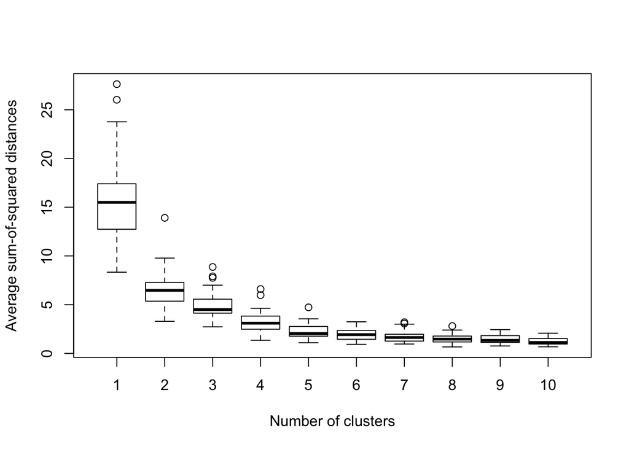

```r
  reps <- 30 # number of repetitions
  testSetSize <- 10 # size of the test set
  Kmax <- 10 # the maximum number of clusters to try

  ss_cv <- matrix(0, reps, Kmax) # create matrix to hold held-out sum of squared errors

  # for each repetition
  for ( it in 1:reps ) {

    # split my data into training and test sets

    # create a random permutation of the numbers 1 ... n
    random_indices <- sample.int(n, n, replace=FALSE) # take a random set of indices from 1...n

    # take the first n-testSetSize numbers to be the indices of the training set
    training_set_indices <- random_indices[1:(n-testSetSize)]

    # take the last testSetSize numbers to be the indices of the test set
    test_set_indices <- random_indices[(n-testSetSize+1):n]

    # create the training and test sets
    x_train <- x[training_set_indices, ]
    x_test <- x[test_set_indices, ]

    # run K-means with a different "k" each time
    for ( k in 1:Kmax ) {

      kc <- kmeans(x_train, k, iter=maxiters) # run k-means on training data

      # now check the fit on the test set data
      ss <- 0 # initialise the sum of squared distances to zero
      # for each test set data point
      for ( i in 1:testSetSize ) {
        # find the cluster which is closest to this data point and record its squared distance
        ss_k <- rep(0, k)
        for ( q in 1: k ) {
          ss_k[q] <- sum( ( x_test[i, ] - kc$centers[q, ] )^2 )
        }
        ss <- ss + min(ss_k)
      }
      # compute the average over the test points
      ss <- ss/testSetSize

      # store
      ss_cv[it, k] <- ss

    }

  }

  # create a boxplot of the distribution of the average sum-of-squared distances for each k
  boxplot(ss_cv, xlab="Number of clusters", ylab="Average sum-of-squared distances")
```

# Principal Components Analysis

## Introduction

[Principal Components Analysis](https://en.wikipedia.org/wiki/Principal_component_analysis) is a statistical technique that can be used to reduce high-dimensional data to a lower-dimensional representation that can be used for either further modelling or visualisation purposes.

There is a great website that gives a graphical illustration of [PCA](http://setosa.io/ev/principal-component-analysis/).

## How it works

The principle behind PCA is this:

1. Each $p$-dimensional data point occupies a point in a $p$-dimensional space.
2. We want to *rotate* the coordinate system of this $p$-dimensional space to create a new coordinate system.
3. The new coordinate system is aligned such that the first axis (the first principal component or PC1) aligns with the direction of greatest variance in the data.
4. The second axis (the second principal component of PC2) is aligned with the direction which has the next greatest variance in the data *AND* is orthogonal to the first axis.
5. We repeat (4) until we have $p$ principal components **or** if $n < p$ we can only fit $n-1$ principal components.

Dimensionality reduction is a potential byproduct. As the higher principal components explain the least amount of variability of data, we can ignore these and only focus on the projection of the original data on to the first few principal component directions.

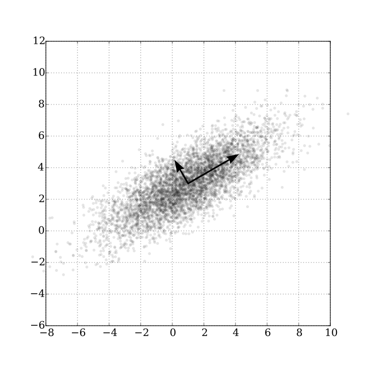

PCA of a multivariate Gaussian distribution centered at (1,3) with a standard deviation of 3 in roughly the (0.866, 0.5) direction and of 1 in the orthogonal direction. The vectors shown are the eigenvectors of the covariance matrix scaled by the square root of the corresponding eigenvalue, and shifted so their tails are at the mean.

Image Source: [Wikipedia](https://en.wikipedia.org/wiki/Principal_component_analysis)

Let us try a code example based on our previous simulation to illustrate the use of the R function prcomp().

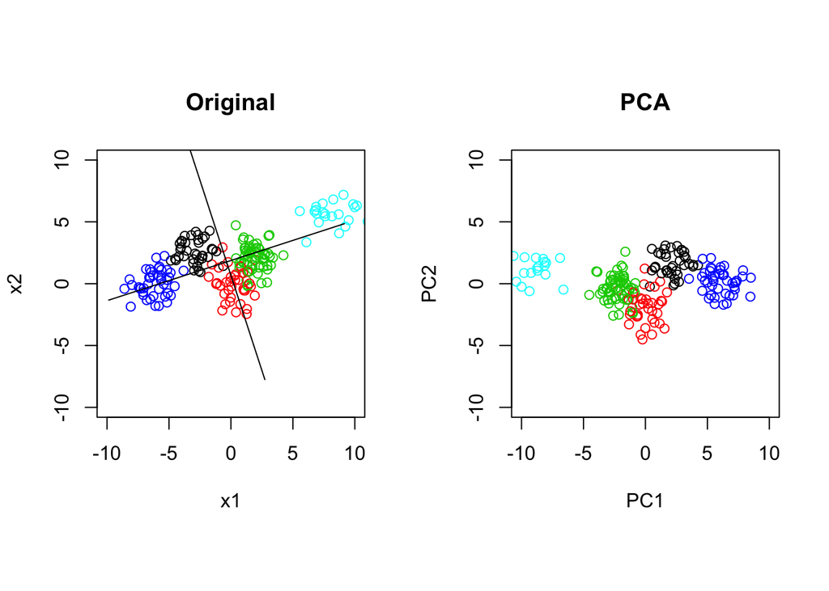

```r
  # set up simulation
  d <- 2 # simulate two-dimensional data
  n <- 200 # simulate 200 data points
  K <- 5 # number of classes
  w <- c(0.2, 0.2, 0.3, 0.2, 0.1) # frequencies of each class
  m <- matrix( nrow=K, ncol=d ) # class centers
  m[1, ] = c(-3, 3)
  m[2, ] = c(0, 0)
  m[3, ] = c(2, 2)
  m[4, ] = c(-6, 0)
  m[5, ] = c(8, 6)
  V <- vector("list", K) # class covariance matrices
  for ( k in 1:K ) {
    V[[k]] <- matrix( c(1,0,0,1), d, d)
  }

  # simulate data
  z <- sample.int(K, n, replace=TRUE, prob=w) # simulate the class assignments
  x <- matrix(nrow=n, ncol=d) # initialise a matrix of zeros to hold simulated data
  for ( i in 1:n ) {
    # get the class assignment for this data point
    k <- z[i]
    # simulate data from a multivariate normal distribution based on the center and covariance matrix for this class
    x[i, ] <- mvrnorm(n = 1, m[k, ], V[[k]])
  }

  # perform principal components analysis
  x_pca <- prcomp(x, center=TRUE)

  # plot the original and transformed data
  par(mfrow=c(1,2), pty="s")

  plot( x[, 1], x[, 2], col=z, main="Original", xlab = "x1", ylab = "x2", xlim=c(-10, 10), ylim=c(-10, 10) )
   lines( c(-10 , 10)*x_pca$rotation[1, 1] + mean(x[, 1]), c(-10, 10)*x_pca$rotation[2, 1] + mean(x[, 2]) )
   lines( c(-10 , 10)*x_pca$rotation[1, 2] + mean(x[, 1]), c(-10, 10)*x_pca$rotation[2, 2] + mean(x[, 2]) )
  plot( x_pca$x[, 1], x_pca$x[, 2], col=z, main="PCA", xlab="PC1", ylab="PC2", xlim=c(-10, 10), ylim=c(-10, 10) )
```

Notice that PCA has effectively rotated the original data so that the first principal components aligns with the direction of greatest variability in the original data. The second principal component is orthogonal to the first component. In this case, there is *no* dimensionality reduction since the original data was two-dimensional and we have retained two principal components.

Now let’s see the dimensionality reduction in practice. In order to do this, we must simulate some high-dimensional data, we do this using the original simulation code but now we are going to have extra dimensions containing noise only.

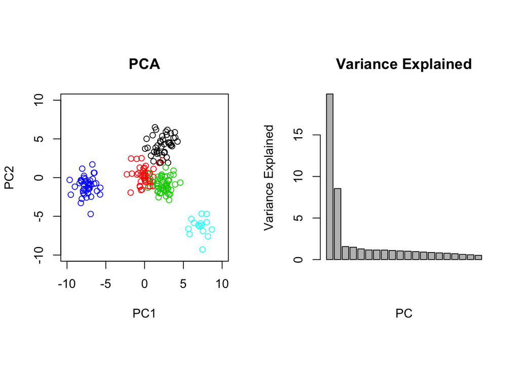

```r
  # set up simulation
  d <- 20 # simulate twenty-dimensional data
  n <- 200 # simulate 200 data points
  K <- 5 # number of classes
  w <- c(0.2, 0.2, 0.3, 0.2, 0.1) # frequencies of each class
  m <- matrix( nrow=K, ncol=d ) # class centers
  m[1, ] = c(-3, 3, rep(0, 18))
  m[2, ] = c(0, 0, rep(0, 18))
  m[3, ] = c(2, 2, rep(0, 18))
  m[4, ] = c(0, -8, rep(0, 18))
  m[5, ] = c(8, 6, rep(0, 18))
  V <- vector("list", K) # class covariance matrices
  for ( k in 1:K ) {
    V[[k]] <- matrix( diag(d), d, d)
  }

  # simulate data
  z <- sample.int(K, n, replace=TRUE, prob=w) # simulate the class assignments
  x <- matrix(nrow=n, ncol=d) # initialise a matrix of zeros to hold simulated data
  for ( i in 1:n ) {
    # get the class assignment for this data point
    k <- z[i]
    # simulate data from a multivariate normal distribution based on the center and covariance matrix for this class
    x[i, ] <- mvrnorm(n = 1, m[k, ], V[[k]])
  }

  # perform principal components analysis
  x_pca <- prcomp(x, center=TRUE)

  # plot the first two components of the transformed data and the variance explained by each PC
  par(mfrow=c(1,2), pty="s")

  plot( x_pca$x[, 1], x_pca$x[, 2], col=z, main="PCA", xlab="PC1", ylab="PC2", xlim=c(-10, 10), ylim=c(-10, 10) )

  barplot( x_pca$sdev^2, main="Variance Explained", xlab="PC", ylab="Variance Explained" )
```

Although the original data is 20-dimensional, the simulation was set up so that only the first two dimensions contained any useful information related the clustering. In the principal component analysis, this meant the first two principal components explained most of the variability in the data.

**EXERCISE**

This is an open-ended exercise for those with more programming experience and who cover the previous material quickly.

1. Test the performance of $k$-means in high-dimensional problems using appropriate simulations. What do you notice in high-dimensions?
2. PCA reduces the dimensionality of data. If we apply PCA first to data and then apply k-means, does this improve or degrade clustering performance?